# Assignment 2

Neriman Gürsoy

11/12/2020

## IMPLEMENTATION OF THE dployr and ggplot2 PACKAGES

## ELECTRICITY MARKET PRICES REPORT

This electricity report shows that implementation and visualization by using dplyr and ggplot2 packages for 01-30 September 2020 EXIST dataset.

## 1.About Energy Exchange Istanbul (EXIST)

Energy Exchange Istanbul (EXIST) was officially established on March 12, 2015 upon the registration processes completed subject to the provisions of the Electricity Market Law of 14.03.2013 numbered 6446 and Turkish Trade Law of 12 Mart 2015 numbered 6102. Main objective and principal business activity is to plan, establish, develop, and manage energy market in a transparent manner that fulfills the requirements of energy market. Energy market in Turkey changes hourly and the related data can be found in the official webpage of EXIST. You can [click](https://rapor.epias.com.tr/rapor/xhtml/ptfSmfListeleme.xhtml) and filter the date you wish to check hourly data.

## 2. About the Dataset

This dataset consists of six different values:

1. Date
2. Market clearing price (MCP)
3. System Marginal Price (SMP)
4. Positive Imbalance Price
5. Negative Imbalance Price
6. System Marginal Price Direction

Before we get into the details of the report, there are a few terms about the dataset that we should mention. These are **energy deficit** and **energy surplus**. If there is a system-wide need for extra electricity production (i.e. actual demand > predicted demand), then it is called an energy Deficit. If the situation is the opposite (i.e. actual demand < predicted demand), then it is called an Energy Surplus. System Marginal Price(SMP) is always higher than Market Clearing Price(MCP) if system has Energy Deficit, and lower if there is Energy Surplus. Market operator also penalizes the operations in BPM by 3%. This is called **Imbalance Price**. Negative (Deficit) Imbalance Price is calculated as max(MCP,SMP)1.03 and Positive Imbalance Price is calculated as min(MCP,SMP)0.97.

## 3. Analysis of the Dataset

After downloading the data between 1 September 2020 and 30 September 2020 from the official webpage of EXIST, the analyses can be started. First of all lubridate, tidyverse and ggplot packages which are used in the report should be loaded. Then we can upload the date which is csv file format.

```r
library (readr)
library (dplyr)
library (tidyverse)
library (lubridate)
library (ggplot2)

Existdata <- read.csv("ptf-smf.csv")
```

We can use the glimpse function to inspect our data. By using it,each column is represented in a row with its data type and first few entries. We have 720 rows and 6 variables.

```r
Existdata %>% glimpse()
```

```
## Rows: 720
## Columns: 6
## $ Date                              <chr> "01.09.20 00:00", "01.09.20 01:00...
## $ MCP                               <dbl> 302.39, 300.25, 292.64, 290.00, 2...
## $ SMP                               <dbl> 332.39, 325.25, 317.64, 320.00, 3...
## $ Positive.Imbalance.Price..TL.MWh. <dbl> 293.32, 291.24, 283.86, 281.30, 2...
## $ Negative.Imbalance.Price..TL.MWh. <dbl> 342.36, 335.01, 327.17, 329.60, 3...
## $ SMP.Direction                     <chr> "? Energy Deficit", "? Energy Def...
```

### 3.1. Rename columns and rearrange the data frame

The *date* column is not date type, to convert from char to datetime.

```r
Existdata$Date <- gsub(pattern = "\\.","-",Existdata$Date)
Existdata$Date <- as.POSIXct(Existdata$Date,format = "%d-%m-%y %H:%M")

Existdata %>% glimpse()
```

```
## Rows: 720
## Columns: 6
## $ Date                              <dttm> 2020-09-01 00:00:00, 2020-09-01 ...
## $ MCP                               <dbl> 302.39, 300.25, 292.64, 290.00, 2...
## $ SMP                               <dbl> 332.39, 325.25, 317.64, 320.00, 3...
## $ Positive.Imbalance.Price..TL.MWh. <dbl> 293.32, 291.24, 283.86, 281.30, 2...
## $ Negative.Imbalance.Price..TL.MWh. <dbl> 342.36, 335.01, 327.17, 329.60, 3...
## $ SMP.Direction                     <chr> "? Energy Deficit", "? Energy Def...
```

Renaming of the columns by using transmute() function in order to have a better comprehension.

```r
raw_df <- Existdata %>% transmute(Date,
                                  MCP = MCP,
                                  SMP = SMP,
                                  PositiveIP = Positive.Imbalance.Price..TL.MWh.,
                                  NegativeIP = Negative.Imbalance.Price..TL.MWh.,
                                  SMPDirection = SMP.Direction )

raw_df %>% glimpse()
```

```
## Rows: 720
## Columns: 6
## $ Date         <dttm> 2020-09-01 00:00:00, 2020-09-01 01:00:00, 2020-09-01 ...
## $ MCP          <dbl> 302.39, 300.25, 292.64, 290.00, 290.00, 290.00, 292.01...
## $ SMP          <dbl> 332.39, 325.25, 317.64, 320.00, 330.00, 339.00, 342.01...
## $ PositiveIP   <dbl> 293.32, 291.24, 283.86, 281.30, 281.30, 281.30, 283.25...
## $ NegativeIP   <dbl> 342.36, 335.01, 327.17, 329.60, 339.90, 349.17, 352.27...
## $ SMPDirection <chr> "? Energy Deficit", "? Energy Deficit", "? Energy Defi...
```

### 3.2. Market clearing price (MCP)

**3.2.1. Hourly MPC**

Since the electricity energy market prices are planned on an hourly basis, it will be useful to find the hourly average, minimum, and maximum values in order to gain some insights about the data.

```r
plot1 <- raw_df %>% group_by(Hour=lubridate::hour(Date)) %>%
  summarize(AvgMCP_Hour=mean(MCP), MinMCP_Hour=min(MCP), MaxMCP_Hour=max(MCP) ) %>%
  print(n=5)
```

```
## # A tibble: 24 x 4
##    Hour AvgMCP_Hour MinMCP_Hour MaxMCP_Hour
##   <int>       <dbl>       <dbl>       <dbl>
## 1     0        298.        268.        314.
## 2     1        294.        268.        310
## 3     2        277.        208.        303.
## 4     3        270.        212.        300.
## 5     4        268.        232.        298.
## # ... with 19 more rows
```

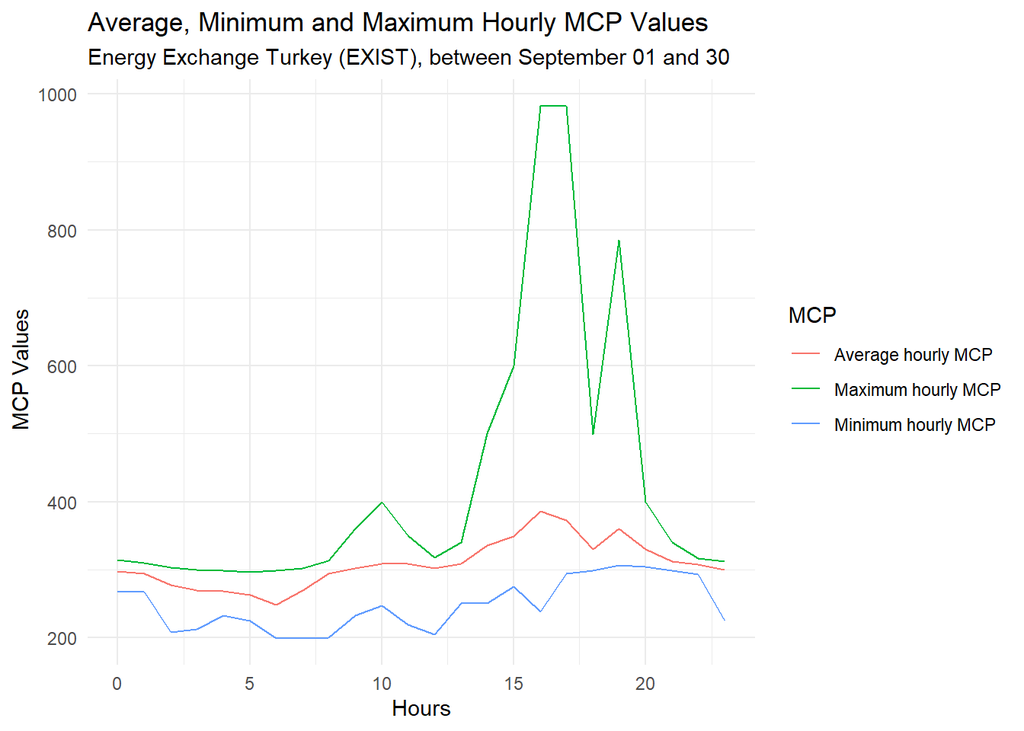

```r
 ggplot(plot1, aes(x=Hour)) +
    geom_line(aes(y = MinMCP_Hour, color = "Minimum hourly MCP"))+
    geom_line(aes(y = MaxMCP_Hour, color = "Maximum hourly MCP"))+
    geom_line(aes(y = AvgMCP_Hour, color = "Average hourly MCP"))+
    labs( title = "Average, Minimum and Maximum Hourly MCP Values",
          subtitle= "Energy Exchange Turkey (EXIST), between September 01 and 30",
          color = "MCP",
          x = "Hours",
          y = " MCP Values")+
    theme_minimal()
```

**3.2.2. Daily MPC**

```r
plot2 <- raw_df %>% group_by(Day=lubridate::day(Date)) %>%
  summarize(AvgMCP_day=mean(MCP), MinMCP_day=min(MCP), MaxMCP_day=max(MCP) ) %>%
  print(n=5)
```

```
## # A tibble: 30 x 4
##     Day AvgMCP_day MinMCP_day MaxMCP_day
##   <int>      <dbl>      <dbl>      <dbl>
## 1     1       322.       290        400
## 2     2       338.       295.       435
## 3     3       337.       295.       430
## 4     4       309.       297.       316.
## 5     5       290.       223.       315.
## # ... with 25 more rows
```

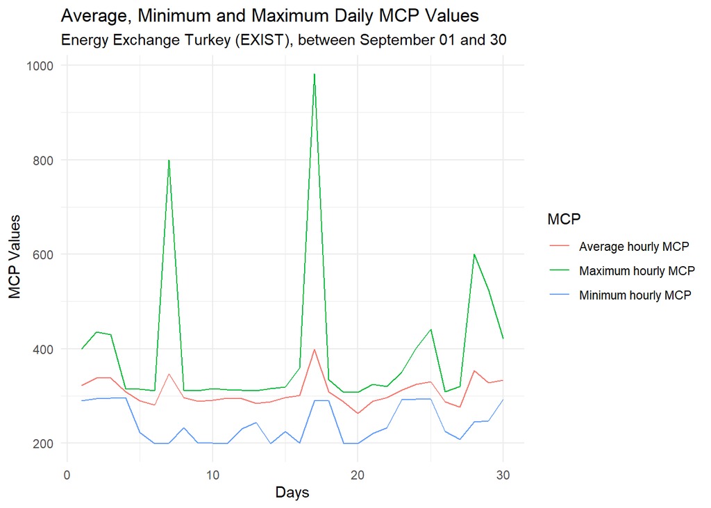

```r
 ggplot(plot2, aes(x=Day)) +
    geom_line(aes(y = MinMCP_day, color = "Minimum hourly MCP"))+
    geom_line(aes(y = MaxMCP_day, color = "Maximum hourly MCP"))+
    geom_line(aes(y = AvgMCP_day, color = "Average hourly MCP"))+
    labs( title = "Average, Minimum and Maximum Daily MCP Values",
          subtitle= "Energy Exchange Turkey (EXIST), between September 01 and 30",
          color = "MCP",
          x = "Days",
          y = " MCP Values")+
    theme_minimal()
```

**3.2.3. Weekly MPC**

Weekly MPC prices for the minimum, maximum, and average values can be seen below. Week numbers correspond to the sequence in a year of 52 weeks.

```r
plot3 <- raw_df %>% group_by(Week=lubridate::week(Date)) %>%
  summarize(AvgMCP_week=mean(MCP), MinMCP_week=min(MCP), MaxMCP_week=max(MCP) ) %>%
  print(n=5)
```

```
## # A tibble: 6 x 4
##    Week AvgMCP_week MinMCP_week MaxMCP_week
##   <dbl>       <dbl>       <dbl>       <dbl>
## 1    35        322.        290         400
## 2    36        314.        199.        800.
## 3    37        291.        198.        319.
## 4    38        306.        199.        982
## 5    39        316.        208.        600.
## # ... with 1 more row
```

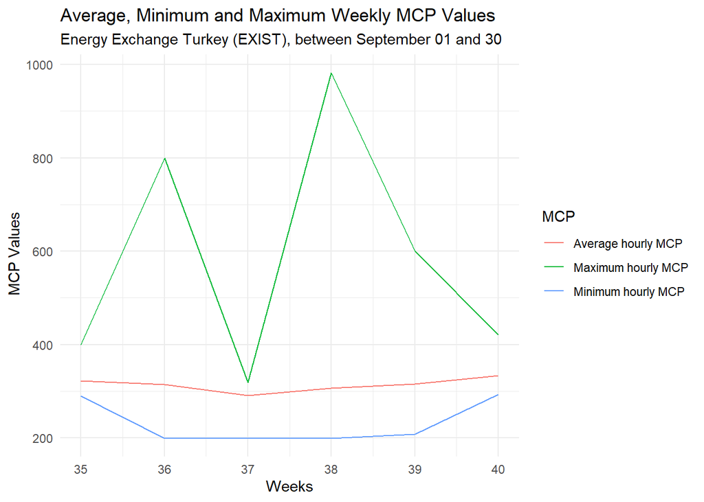

```r
 ggplot(plot3, aes(x=Week)) +
    geom_line(aes(y = MinMCP_week, color = "Minimum hourly MCP"))+
    geom_line(aes(y = MaxMCP_week, color = "Maximum hourly MCP"))+
    geom_line(aes(y = AvgMCP_week, color = "Average hourly MCP"))+
    labs( title = "Average, Minimum and Maximum Weekly MCP Values",
          subtitle= "Energy Exchange Turkey (EXIST), between September 01 and 30",
          color = "MCP",
          x = "Weeks",
          y = " MCP Values")+
    theme_minimal()
```

### 3.3. System Marginal Price (SMP)

**3.3.1. Daily change of the SMP**

```r
plot4 <- raw_df %>% group_by(Day=lubridate::day(Date)) %>%
  summarize(AvgSMP_day=mean(SMP), MinSMP_day=min(SMP), MaxSMP_day=max(SMP)) %>%
  ungroup()
  plot4
```

```
## # A tibble: 30 x 4
##      Day AvgSMP_day MinSMP_day MaxSMP_day
##    <int>      <dbl>      <dbl>      <dbl>
##  1     1       370.       318.       480
##  2     2       389.       323.       540
##  3     3       467.       219.      2000
##  4     4       344.       218.       395.
##  5     5       229.       201        307.
##  6     6       274.       199.       330.
##  7     7       316.       129        800.
##  8     8       307.       211.       345
##  9     9       290.       198        335.
## 10    10       314.       215        356.
## # ... with 20 more rows
```

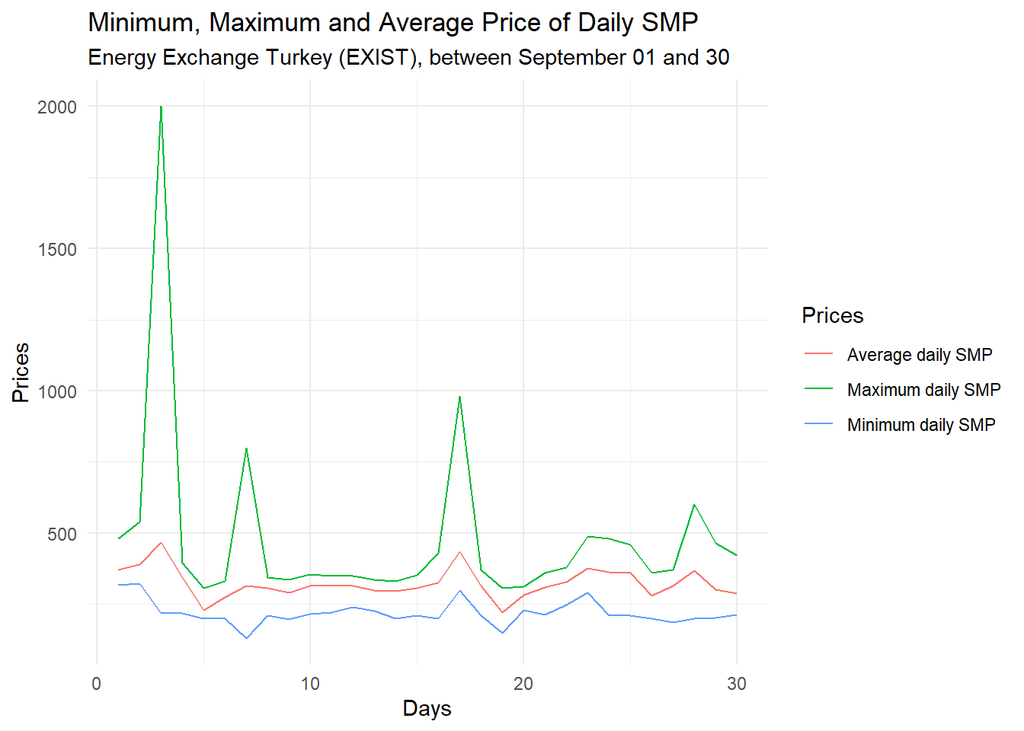

```r
    ggplot(plot4, aes(x=Day, color = "Days"))+
    geom_line(aes(y = AvgSMP_day, color = "Average daily SMP")) +
    geom_line(aes(y = MinSMP_day, color = "Minimum daily SMP")) +
    geom_line(aes(y = MaxSMP_day, color = "Maximum daily SMP")) +
    theme_minimal() +
    labs(title = "Minimum, Maximum and Average Price of Daily SMP",
         subtitle = "Energy Exchange Turkey (EXIST), between September 01 and 30",
         x= "Days",
         y= "Prices",
         color = "Prices")
```

### 3.4.Relationship between MCP and SMP

We can the following plot in order to obtain daily average of the MCP and SMP.

```r
plot5 <- raw_df %>%
        group_by(Day = lubridate::day(Date))%>%
        summarise(Average_MCP = mean(MCP),
                  Average_SMP = mean(SMP),
                  Difference = abs(mean(MCP) - mean(SMP))) %>%
        ungroup()%>%
        arrange(desc(Difference))

knitr::kable(plot5, format="markdown")
```

| Day | Average_MCP | Average_SMP | Difference |
| --- | --- | --- | --- |
| 3 | 337.4887 | 467.0421 | 129.553333 |
| 19 | 287.3604 | 221.7283 | 65.632083 |
| 23 | 312.2346 | 376.2304 | 63.995833 |
| 5 | 290.0550 | 229.4754 | 60.579583 |
| 2 | 338.0446 | 388.9433 | 50.898750 |
| 1 | 322.0288 | 370.3571 | 48.328333 |
| 30 | 333.7412 | 287.0933 | 46.647917 |
| 27 | 276.1329 | 316.0517 | 39.918750 |
| 17 | 398.2517 | 436.4633 | 38.211667 |
| 24 | 324.1646 | 362.2946 | 38.130000 |
| 4 | 308.8050 | 344.4458 | 35.640833 |
| 22 | 296.9675 | 329.5946 | 32.627083 |
| 7 | 346.4404 | 316.0987 | 30.341667 |
| 25 | 330.3375 | 359.5421 | 29.204583 |
| 29 | 327.7971 | 301.5158 | 26.281250 |
| 10 | 290.4287 | 313.9346 | 23.505833 |
| 16 | 301.2887 | 324.4992 | 23.210417 |
| 12 | 294.1600 | 315.4725 | 21.312500 |
| 21 | 288.8883 | 309.1775 | 20.289167 |
| 11 | 295.2833 | 314.1946 | 18.911250 |
| 20 | 263.3279 | 281.5925 | 18.264583 |
| 28 | 353.0358 | 367.9879 | 14.952083 |
| 13 | 284.5521 | 298.3087 | 13.756667 |
| 15 | 296.2783 | 306.9983 | 10.720000 |
| 8 | 296.3679 | 306.6333 | 10.265417 |
| 14 | 286.9396 | 296.3225 | 9.382917 |
| 26 | 288.0075 | 281.2779 | 6.729583 |
| 6 | 280.5050 | 274.0179 | 6.487083 |
| 18 | 308.9604 | 315.2442 | 6.283750 |
| 9 | 288.2262 | 289.9971 | 1.770833 |

**Graph of the daily average value of MCP and SMP with line graph:**

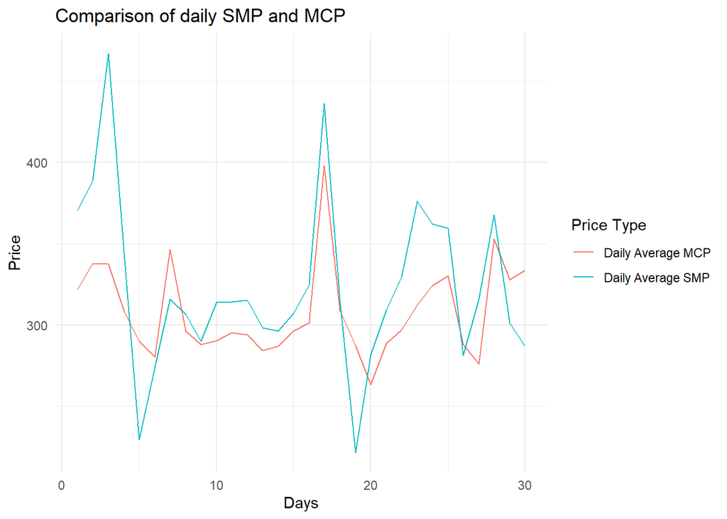

```r
  ggplot(plot5, aes(x = Day)) +
    geom_line(aes(y = Average_MCP, color = "Daily Average MCP")) +
    geom_line(aes(y = Average_SMP, color = "Daily Average SMP")) +
    theme_minimal() +
    labs(title = "Comparison of daily SMP and MCP",
         x="Days",
         y="Price",
         color="Price Type")
```

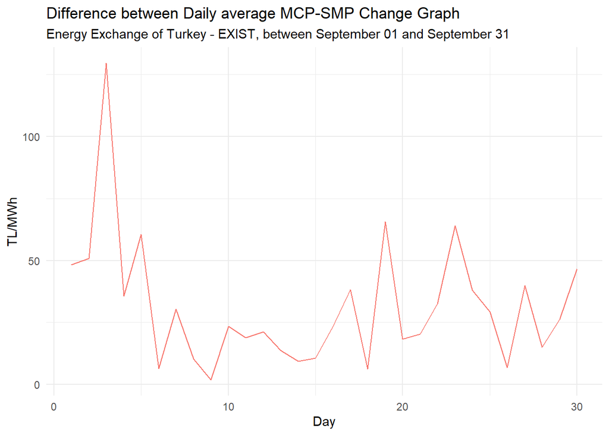

```r
  ggplot(plot5, aes(x=Day)) +
    geom_line(aes(y = Difference, color = "Difference of average values")) +
    labs(x = "Day", y = "TL/MWh",
       title = "Difference between Daily average MCP-SMP Change Graph",
       subtitle = "Energy Exchange of Turkey - EXIST, between September 01 and September 31 ")+
  theme_minimal() +
  theme(legend.position = "center")
```

The graph shows that the highest difference between daily average value of SMP and MPC is observed in the third day.

**Graph of the weekly average value of MCP and SCP with bar graph:**

```r
  plot6 <-raw_df %>%
  group_by(Week = lubridate::week(Date)) %>%
  summarise(Weekly_MCP = mean(MCP),
            Weekly_SMP = mean(SMP),
            Difference = abs(mean(MCP) - mean(SMP))) %>%
  ungroup() %>%
  arrange(desc(Difference))
plot6
```

```
## # A tibble: 6 x 4
##    Week Weekly_MCP Weekly_SMP Difference
##   <dbl>      <dbl>      <dbl>      <dbl>
## 1    35       322.       370.       48.3
## 2    40       334.       287.       46.6
## 3    39       316.       338.       21.9
## 4    36       314.       332.       18.4
## 5    37       291.       305.       14.2
## 6    38       306.       317.       10.5
```

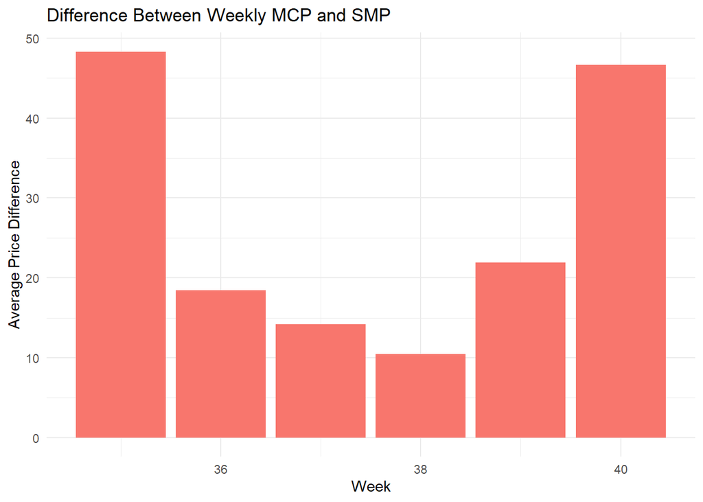

```r
 ggplot(plot6,aes(x = Week, y = Difference, fill = "Weeks")) +
    geom_bar(stat = "identity") +
    theme_minimal()+
    theme(legend.position = "none") +
    labs(title = "Difference Between Weekly MCP and SMP ",
         x = "Week",
         y = "Average Price Difference")
```

**Scatter Graph of the relationship between MCP and SMP values:**

The plot below shows that for most of the days, MCP lies 200-400 and SMP lies 100-500. Also we can say that there is an outlier value which SMP is equal 2000.

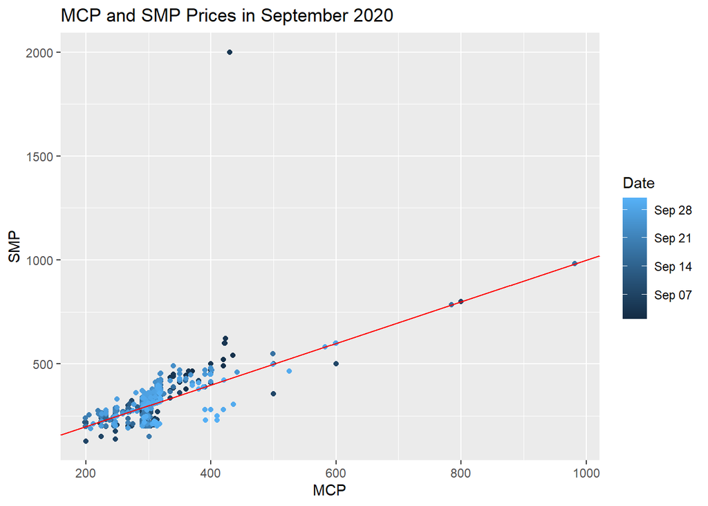

```r
  ggplot(raw_df, aes(x=MCP, y=SMP, color=Date)) +
  geom_point() +
  labs(x="MCP", y="SMP",  title="MCP and SMP Prices in September 2020") +
  theme_get() +
  geom_abline(slope=1, intercept=0, color="red")
```

### 3.5. Negative and positive imbalance

3.5.1. Negative and positive imbalance price in first day

Negative and Positive imbalance prices can be seen below for the first day of the September, 2020.

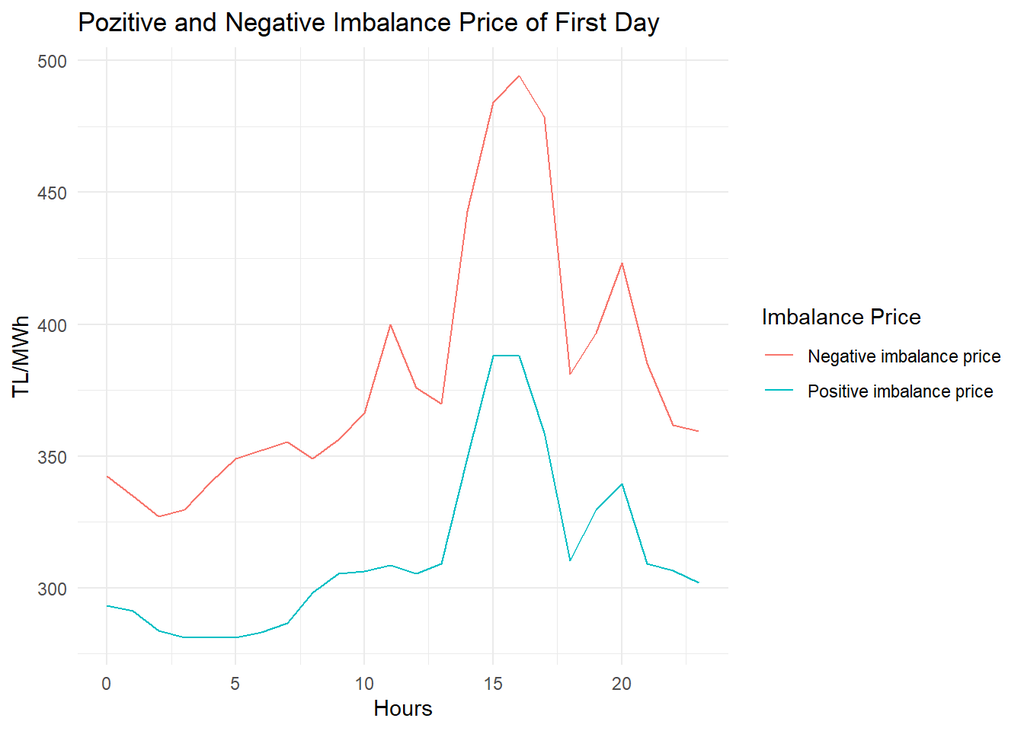

```r
raw_df %>%
  select(Date, PositiveIP, NegativeIP)%>%
  group_by(Day = lubridate::day(Date), Hour = lubridate::hour(Date))%>%
  select(Day,Hour, PositiveIP, NegativeIP)%>%
  filter(Day==1)%>%

  ggplot(aes(Hour, color = "Hours"))+
    geom_line(aes(y=PositiveIP, color = "Positive imbalance price")) +
    geom_line(aes(y=NegativeIP, color = "Negative imbalance price")) +
    labs(x = "Hours", y = "TL/MWh",
         title= "Pozitive and Negative Imbalance Price of First Day",
         color = "Imbalance Price") +
    theme_minimal()
```

Negative and Positive imbalance prices can be seen below for the last day of the September, 2020.

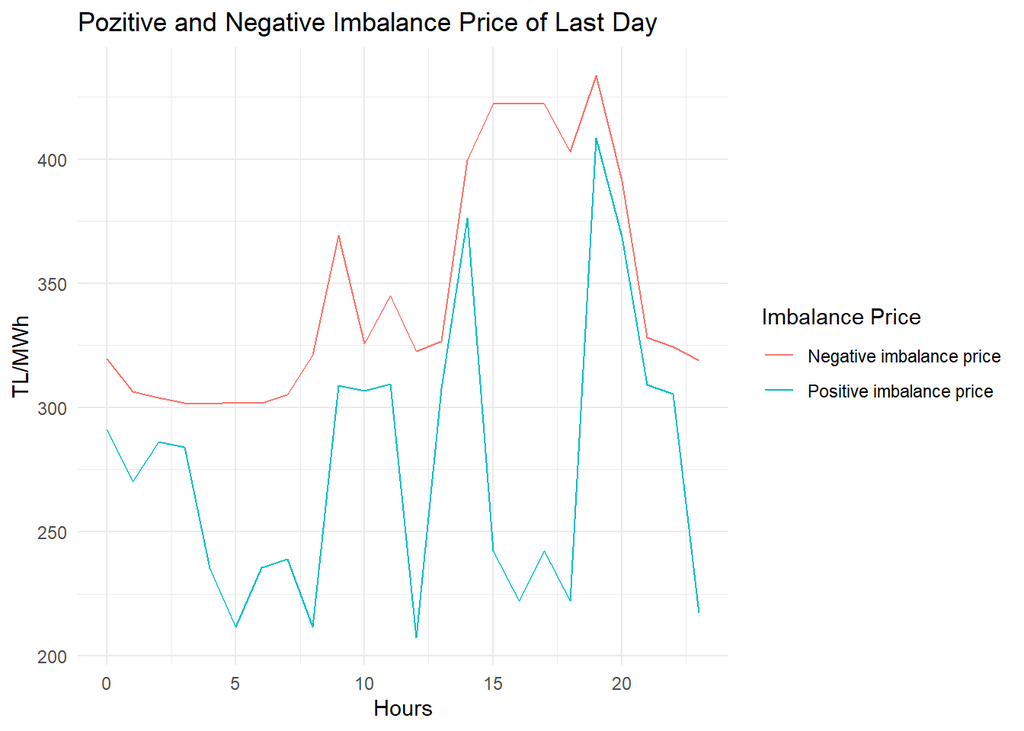

```r
raw_df %>%
  select(Date, PositiveIP, NegativeIP)%>%
  group_by(Day = lubridate::day(Date), Hour = lubridate::hour(Date))%>%
  select(Day,Hour, PositiveIP, NegativeIP)%>%
  filter(Day==30)%>%

  ggplot(aes(Hour, color = "Hours"))+
    geom_line(aes(y=PositiveIP, color = "Positive imbalance price")) +
    geom_line(aes(y=NegativeIP, color = "Negative imbalance price")) +
    labs(x = "Hours", y = "TL/MWh",
         title= "Pozitive and Negative Imbalance Price of Last Day",
         color = "Imbalance Price") +
    theme_minimal()
```

3.5.3. Graph of daily difference of negative and positive imbalance price

```r
  plot7<-raw_df %>%
        select(Date, PositiveIP, NegativeIP)%>%
        group_by(Day = lubridate::day(Date), Hour = lubridate::hour(Date))%>%
        select(Day,Hour, PositiveIP, NegativeIP)%>%
        transmute(Day,Hour,PositiveIP, NegativeIP, difference=NegativeIP-PositiveIP)%>%
        ungroup()%>%
        arrange(desc(difference)) %>%
        print(n=5)
```

```
## # A tibble: 720 x 5
##     Day  Hour PositiveIP NegativeIP difference
##   <int> <int>      <dbl>      <dbl>      <dbl>
## 1     3    16       417.      2060       1643.
## 2     3    15       411.       640.       229.
## 3     3    14       409.       617.       208.
## 4     3    17       410.       617.       207.
## 5    30    16       222.       422.       200.
## # ... with 715 more rows
```

### 3.6. SMP Direction

These are **energy deficit**, **energy surplus**, and **energy balance** due to the relationship between actual demand and predicted demand. In the data we examine, there are energy deficit, surplus and balance states on an hourly basis. This information is given in the column called SMP Direction.

```r
plot8 <- raw_df %>% group_by(SMPDirection) %>% summarize(count=n())%>%print()
```

```
## # A tibble: 3 x 2
##   SMPDirection     count
##   <chr>            <int>
## 1 ? Energy Deficit   547
## 2 ? In Balance        38
## 3 ?Energy Surplus    135
```

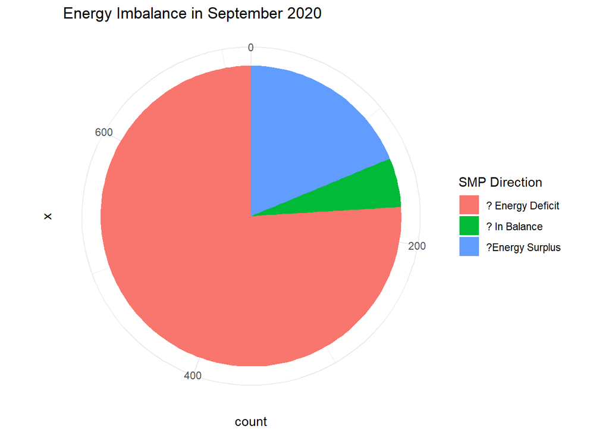

```r
ggplot(plot8, aes(x="", y=count, fill=SMPDirection)) + geom_bar(stat="identity", width=1) +
  coord_polar("y") +
  theme_minimal() +
  labs( title="Energy Imbalance in September 2020",
        fill="SMP Direction")
```

3.6.1. Hourly Energy Deficit, Energy Surplus,and Balance Distribution

```r
plot9 <- raw_df %>% group_by(Hour=lubridate::hour(Date)) %>%
         summarise(Surplus=sum(MCP>SMP), Deficit=sum(MCP<SMP), Balance=sum(MCP==SMP)) %>%
         ungroup() %>%
         select(Hour, Surplus, Deficit, Balance) %>%
         print(n=5)
```

```
## # A tibble: 24 x 4
##    Hour Surplus Deficit Balance
##   <int>   <int>   <int>   <int>
## 1     0       9      20       1
## 2     1       9      14       7
## 3     2       7      16       7
## 4     3       5      12      13
## 5     4       8      16       6
## # ... with 19 more rows
```

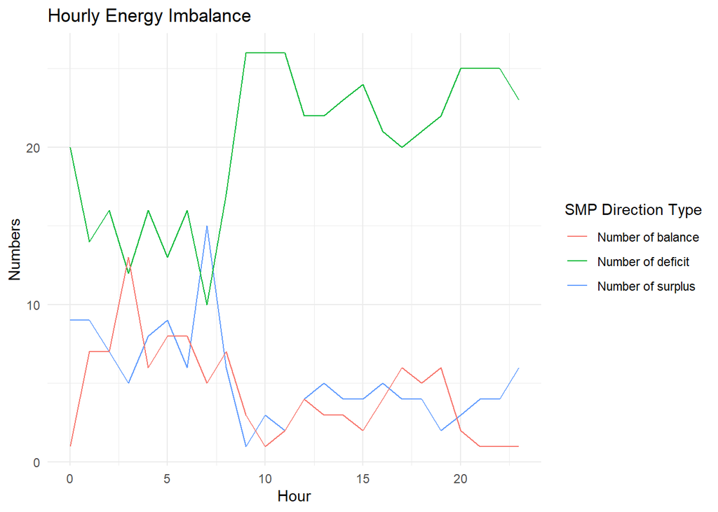

```r
  ggplot(plot9, aes(x = Hour, color = "Hours")) +
    geom_line(aes(y = Surplus, color = "Number of surplus")) +
    geom_line(aes(y = Deficit, color = "Number of deficit")) +
    geom_line(aes(y = Balance, color = "Number of balance")) +

  labs(x = "Hour",
       y = "Numbers",
       title = "Hourly Energy Imbalance",
       color = "SMP Direction Type") +
  theme_minimal()
```

3.6.2. Graph of the Hourly Deficit Energy Usage

```r
plot10 <- raw_df %>%
        group_by(Hours = lubridate::hour(Date))%>%
        transmute(EnergyUsage = ifelse(SMPDirection == "?Energy Surplus", "Surplus", "Deficit")) %>%
        group_by(EnergyUsage, Hours) %>%
        filter(EnergyUsage=="Deficit") %>%
        summarise(Number = n())%>%
        print(n=5)
```

```
## # A tibble: 24 x 3
## # Groups:   EnergyUsage [1]
##   EnergyUsage Hours Number
##   <chr>       <int>  <int>
## 1 Deficit         0     21
## 2 Deficit         1     21
## 3 Deficit         2     23
## 4 Deficit         3     24
## 5 Deficit         4     22
## # ... with 19 more rows
```

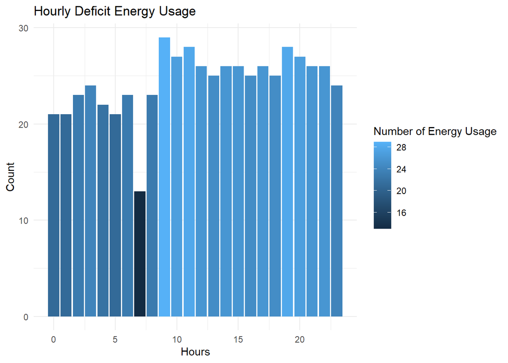

```r
  ggplot(plot10, aes(x = Hours, y = Number, fill = Number)) +
         geom_bar(stat = "identity") +
         theme_minimal() +
         labs(title = "Hourly Deficit Energy Usage ",
         fill = "Number of Energy Usage",
         x="Hours",
         y = "Count")
```